# Mathematics and R Laboratory – Exercise Dataset Report

Alessio Giannotta

30 September 2026

## Purpose

This report demonstrates the type of R / R Markdown pipeline I build and maintain for the Mathematics and R Laboratory course I teach: it reads a raw exercise dataset, checks and cleans it, computes descriptive statistics, and produces visualisations, all compiled automatically into a single reproducible document.

The dataset used here is **synthetic** (see `generate_data.R`): no real student data is included in this repository.

## 1. Reading the raw data

```r
raw <- read.csv("data/lab_exercise_data.csv", stringsAsFactors = FALSE)
str(raw)
```

```
## 'data.frame':    120 obs. of  6 variables:
##  $ student_id    : chr  "S001" "S002" "S003" "S004" ...
##  $ cohort        : chr  "2024/2025" "2024/2025" "2024/2025" "2024/2025" ...
##  $ hours_studied : num  10.5 12.7 14.3 17.6 9.1 17.2 13.3 16.2 15.7 14.9 ...
##  $ attendance_pct: num  73.6 79.2 56.8 98.8 78.6 75 77 95.5 63.4 57.3 ...
##  $ written_score : num  145 29 30.3 30.2 17.1 34.2 29.1 23.9 27.5 19.1 ...
##  $ lab_score     : num  22.6 21.6 24.1 24.7 25.4 25 33.6 20.5 24.3 27.4 ...
```

## 2. Data quality checks and cleaning

Before any analysis, I check for missing values and implausible entries (e.g. scores outside the valid 0-30 range), which routinely occur in raw exercise/exam datasets.

```r
missing_summary <- colSums(is.na(raw))
missing_summary
```

```
##     student_id         cohort  hours_studied attendance_pct  written_score
##              0              0              0              3              5
##      lab_score
##              0
```

```r
out_of_range <- raw %>%
  filter(written_score < 0 | written_score > 30 | is.na(written_score))
out_of_range
```

```
##    student_id    cohort hours_studied attendance_pct written_score lab_score
## 1        S001 2024/2025          10.5           73.6         145.0      22.6
## 2        S003 2024/2025          14.3           56.8          30.3      24.1
## 3        S004 2024/2025          17.6           98.8          30.2      24.7
## 4        S006 2025/2026          17.2           75.0          34.2      25.0
## 5        S015 2024/2025           9.8           82.6          30.5      31.8
## 6        S036 2025/2026           8.6           69.4          30.5      30.4
## 7        S039 2025/2026          12.3           73.1          30.9      25.0
## 8        S040 2025/2026          14.6           44.5            NA      29.7
## 9        S047 2025/2026          10.3           98.8          36.3      26.0
## 10       S054 2025/2026          10.0           83.3          35.1      23.0
## 11       S055 2025/2026           5.4           48.8            NA      22.9
## 12       S075 2025/2026          17.8           95.8            NA      25.8
## 13       S085 2024/2025          10.3           58.1          33.0      29.8
## 14       S097 2024/2025          12.0           55.3            NA      32.5
## 15       S101 2025/2026          11.3           63.6          -3.0      29.3
## 16       S110 2024/2025          15.6             NA          30.8      23.2
## 17       S114 2024/2025          18.8           97.1            NA      16.2
```

```r
clean <- raw %>%
  filter(!is.na(attendance_pct)) %>%
  mutate(
    written_score = ifelse(written_score < 0 | written_score > 30,
                            NA, written_score)
  ) %>%
  filter(!is.na(written_score))

cat("Rows before cleaning:", nrow(raw), "\n")
```

```
## Rows before cleaning: 120
```

```r
cat("Rows after cleaning: ", nrow(clean), "\n")
```

```
## Rows after cleaning:  101
```

## 3. Aggregation

Cross-checking written and lab scores by cohort, similar to how grades are aggregated and cross-checked across written and lab-based assessments for the examination committee.

```r
summary_by_cohort <- clean %>%
  group_by(cohort) %>%
  summarise(
    n              = n(),
    mean_written   = round(mean(written_score), 2),
    mean_lab       = round(mean(lab_score), 2),
    sd_written     = round(sd(written_score), 2),
    median_written = median(written_score)
  )

summary_by_cohort
```

```
## # A tibble: 2 x 6
##   cohort        n mean_written mean_lab sd_written median_written
##   <chr>     <int>        <dbl>    <dbl>      <dbl>          <dbl>
## 1 2024/2025    45         23.0     25.8       4.48           23.8
## 2 2025/2026    56         23.4     26.2       3.89           23.8
```

## 4. Descriptive statistics

```r
summary(clean[, c("hours_studied", "attendance_pct",
                   "written_score", "lab_score")])
```

```
##  hours_studied   attendance_pct written_score     lab_score
##  Min.   : 3.90   Min.   :40.1   Min.   :10.50   Min.   :17.20
##  1st Qu.: 9.30   1st Qu.:51.3   1st Qu.:20.20   1st Qu.:23.60
##  Median :11.80   Median :67.8   Median :23.80   Median :25.90
##  Mean   :11.75   Mean   :67.6   Mean   :23.23   Mean   :26.04
##  3rd Qu.:14.40   3rd Qu.:79.9   3rd Qu.:26.40   3rd Qu.:28.40
##  Max.   :22.80   Max.   :98.8   Max.   :29.90   Max.   :37.90
```

## 5. Visualisation

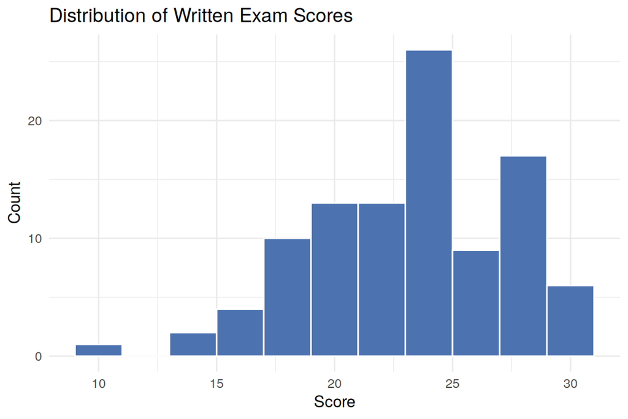

```r
ggplot(clean, aes(x = written_score)) +
  geom_histogram(binwidth = 2, fill = "#4C72B0", color = "white") +
  labs(title = "Distribution of Written Exam Scores",
       x = "Score", y = "Count") +
  theme_minimal()
```

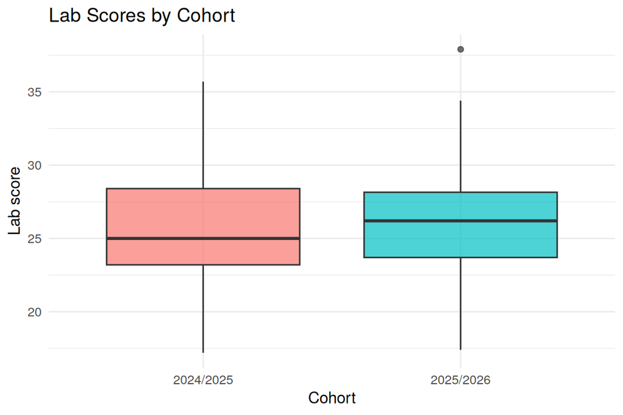

```r
ggplot(clean, aes(x = cohort, y = lab_score, fill = cohort)) +
  geom_boxplot(alpha = 0.7) +
  labs(title = "Lab Scores by Cohort",
       x = "Cohort", y = "Lab score") +
  theme_minimal() +
  theme(legend.position = "none")
```

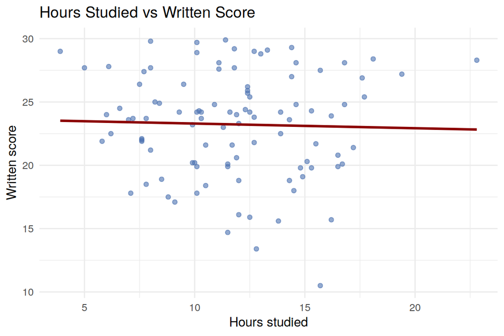

```r
ggplot(clean, aes(x = hours_studied, y = written_score)) +
  geom_point(alpha = 0.6, color = "#4C72B0") +
  geom_smooth(method = "lm", se = FALSE, color = "darkred") +
  labs(title = "Hours Studied vs Written Score",
       x = "Hours studied", y = "Written score") +
  theme_minimal()
```

## 6. A simple regression check

```r
model <- lm(written_score ~ hours_studied + attendance_pct, data = clean)
summary(model)
```

```
##
## Call:
## lm(formula = written_score ~ hours_studied + attendance_pct,
##     data = clean)
##
## Residuals:
##      Min       1Q   Median       3Q      Max
## -11.9450  -2.9367   0.3015   3.0919   7.0543
##
## Coefficients:
##                Estimate Std. Error t value Pr(>|t|)
## (Intercept)    21.40909    2.12356  10.082   <2e-16 ***
## hours_studied  -0.04516    0.11756  -0.384    0.702
## attendance_pct  0.03483    0.02408   1.446    0.151
## ---
## Signif. codes:  0 '***' 0.001 '**' 0.01 '*' 0.05 '.' 0.1 ' ' 1
##
## Residual standard error: 4.139 on 98 degrees of freedom
## Multiple R-squared:  0.02186,    Adjusted R-squared:  0.001897
## F-statistic: 1.095 on 2 and 98 DF,  p-value: 0.3386
```

## Notes

This document is knit directly from the underlying CSV: updating `data/lab_exercise_data.csv` (or re-running `generate_data.R`) and re-knitting reproduces the full report – the same reproducible workflow used for the lab sessions.